# STA3020 - QUIZ 1

2024-01-30

> Name: Chesia Anyika

> ID: 665567

# Question

Air pollution is currently one of the most serious public health worries worldwide. Many epidemiological studies have proved the influence that some chemical compounds can have on our health. Associations set up to monitor air quality are active all over the world to measure the concentration of these pollutants. They also keep a record of meteorological conditions such as temperature (T9, T12, T15), cloud cover (C9, C12, C15), wind (W9, W12, W15). The data-set is within the `fdm2id` package.

The final aim is to analyse the relationship between the maximum daily ozone level and meteorological conditions. You have at our disposal 112 observations collected. You need to inspect the data with a PCA and illustrate the reconstruction property of PCA. The variables available are max O3 (maximum daily ozone), Temperature at 0900HRS, 1200HRS & 1500HRS (T9, T12, T15), cloud cover at 0900HRS, 1200HRS & 1500HRS (C9, C12, C15), and wind speed at 0900HRS, 1200HRS & 1500HRS (W9, W12, W15):

− Perform the PCA on the ozone data and give a short interpretation of the dimensions of variability (interpretation of the observations plot, correlation between variables, percentage of variability, etc.)

# Execution

## Libraries

```r
# library that contains the ozone dataset
library(fdm2id)
```

```r
# library for visualisation of correlation matrices
library(ggcorrplot)
# library with PCA module
library(FactoMineR)

# library for visualisation of PCA outputs
library(factoextra)
```

## Exploratory Data Analysis

I loaded the required data and explored the data-set’s characteristics, such as its column names and dimensions.

```r
#load ozone data
data("ozone")

#view the first 5 entries of the dataset
head(ozone)
```

```
##          maxO3   T9  T12  T15 C9 C12 C15      W9     W12     W15
## 20010601    87 15.6 18.5 18.4  4   4   8  0.6946 -1.7101 -0.6946
## 20010602    82 17.0 18.4 17.7  5   5   7 -4.3301 -4.0000 -3.0000
## 20010603    92 15.3 17.6 19.5  2   5   4  2.9544  1.8794  0.5209
## 20010604   114 16.2 19.7 22.5  1   1   0  0.9848  0.3473 -0.1736
## 20010605    94 17.4 20.5 20.4  8   8   7 -0.5000 -2.9544 -4.3301
## 20010606    80 17.7 19.8 18.3  6   6   7 -5.6382 -5.0000 -6.0000
```

I used the `summary()` function to get a detailed description of the datatypes and variables within the data-set, as well as the column names of the 10 variables, as shown below.

```r
#check the data type of the data
summary(ozone)
```

```
##      maxO3              T9             T12             T15
##  Min.   : 42.00   Min.   :11.30   Min.   :14.00   Min.   :14.90
##  1st Qu.: 70.75   1st Qu.:16.20   1st Qu.:18.60   1st Qu.:19.27
##  Median : 81.50   Median :17.80   Median :20.55   Median :22.05
##  Mean   : 90.30   Mean   :18.36   Mean   :21.53   Mean   :22.63
##  3rd Qu.:106.00   3rd Qu.:19.93   3rd Qu.:23.55   3rd Qu.:25.40
##  Max.   :166.00   Max.   :27.00   Max.   :33.50   Max.   :35.50
##        C9             C12             C15             W9
##  Min.   :0.000   Min.   :0.000   Min.   :0.00   Min.   :-7.8785
##  1st Qu.:3.000   1st Qu.:4.000   1st Qu.:3.00   1st Qu.:-3.2765
##  Median :6.000   Median :5.000   Median :5.00   Median :-0.8660
##  Mean   :4.929   Mean   :5.018   Mean   :4.83   Mean   :-1.2143
##  3rd Qu.:7.000   3rd Qu.:7.000   3rd Qu.:7.00   3rd Qu.: 0.6946
##  Max.   :8.000   Max.   :8.000   Max.   :8.00   Max.   : 5.1962
##       W12              W15
##  Min.   :-7.878   Min.   :-9.000
##  1st Qu.:-3.565   1st Qu.:-3.939
##  Median :-1.879   Median :-1.550
##  Mean   :-1.611   Mean   :-1.691
##  3rd Qu.: 0.000   3rd Qu.: 0.000
##  Max.   : 6.578   Max.   : 5.000
```

All the variables are numeric, which is good as PCA can only be performed on numeric variables. The data is organised such that the variables are arranged column-wise, and the observations are arranged row-wise.

```r
#get the dimensions of the dataset
dim(ozone)
```

```
## [1] 112  10
```

Finally we can use the `is.na()` function to check for null values, before we begin with the Principal Component Analysis.

```r
# check for null values
colSums(is.na(ozone))
```

```
## maxO3    T9   T12   T15    C9   C12   C15    W9   W12   W15
##     0     0     0     0     0     0     0     0     0     0
```

The code above shows there are no null values in this data-set that need to be dealt with.

## Principal Component Analysis (PCA)

### Step 1: Standardisation of data

The next step is to standardise the data, in order to give equal weight to all the variables. This is because the variables of **Temperature, Cloud cover and Wind Speed** are all measured using different units. Scaling ensures the variables with different scales do not disproportionately influence the results of the PCA.

Standardisation is usually performed by subtracting the mean from an observation then dividing the result by the standard deviation. This is repeated for all observations, as per the formula:

$$Z_{ij} = \frac{X_{ij} - \bar{x_{ij}}}{s_{j}}$$

Where:

- $Z_{ij}$ represents the standardised observation for variable j in sample unit i
- $X_{ij}$ represents the data for variable j in sample unit i
- $\bar{x_{j}}$ represents the mean
- $s_{j}$ represents the standard deviation for variable j

In r, I used the `scale()` function to implement this, as shown below.

```r
#standardise the data
ozone_std <- scale(ozone)

#Get a summary of the data
summary(ozone_std)
```

```
##      maxO3               T9               T12               T15
##  Min.   :-1.7137   Min.   :-2.2611   Min.   :-1.8620   Min.   :-1.7056
##  1st Qu.:-0.6937   1st Qu.:-0.6919   1st Qu.:-0.7240   1st Qu.:-0.7400
##  Median :-0.3123   Median :-0.1796   Median :-0.2416   Median :-0.1275
##  Mean   : 0.0000   Mean   : 0.0000   Mean   : 0.0000   Mean   : 0.0000
##  3rd Qu.: 0.5569   3rd Qu.: 0.5009   3rd Qu.: 0.5005   3rd Qu.: 0.6119
##  Max.   : 2.6855   Max.   : 2.7666   Max.   : 2.9620   Max.   : 2.8410
##        C9               C12                 C15                 W9
##  Min.   :-1.8993   Min.   :-2.199021   Min.   :-2.07111   Min.   :-2.5313
##  1st Qu.:-0.7432   1st Qu.:-0.446065   1st Qu.:-0.78480   1st Qu.:-0.7833
##  Median : 0.4129   Median :-0.007826   Median : 0.07274   Median : 0.1323
##  Mean   : 0.0000   Mean   : 0.000000   Mean   : 0.00000   Mean   : 0.0000
##  3rd Qu.: 0.7983   3rd Qu.: 0.868652   3rd Qu.: 0.93028   3rd Qu.: 0.7251
##  Max.   : 1.1836   Max.   : 1.306891   Max.   : 1.35904   Max.   : 2.4349
##       W12               W15
##  Min.   :-2.2419   Min.   :-2.60100
##  1st Qu.:-0.6988   1st Qu.:-0.80013
##  Median :-0.0960   Median : 0.05019
##  Mean   : 0.0000   Mean   : 0.00000
##  3rd Qu.: 0.5762   3rd Qu.: 0.60162
##  Max.   : 2.9291   Max.   : 2.38086
```

The summary of the data shows that the values are now standardised.

### Step 2: Applying PCA

#### Method : Using the Correlation Matrix.

**Step 1: Compute the Correlation Matrix**

Where

- $r$ represents the Pearson’s Correlation Coefficient
- $cov(X,Y)$ represents the covariance between variables X and Y
- $\sqrt(var(X))$ represents the square root of the variance of variable X
- $\sqrt(var(Y))$ represents the square root of the variance of variable Y

To implement this in r, I used the `cor()` function, then visualised the resultant correlation matrix in a correlation heat-map using the `ggcorrplot()` function.

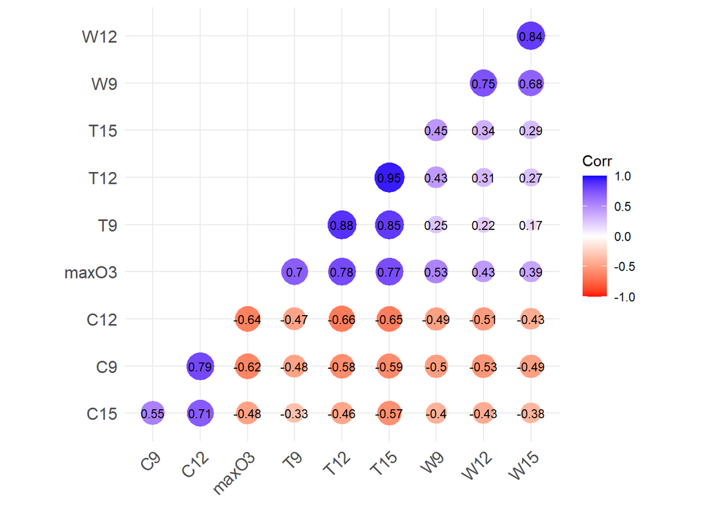

```r
#Compute the Pearson's coefficient
matc <- cor(ozone)
corMatrix <- cor(ozone_std)

# correlation heat map
ggcorrplot(corMatrix,
           hc.order = TRUE,
           type = "lower",
           ggtheme = theme_minimal(),
           lab = TRUE,
           lab_size = 3,
           method = "circle",
           outline.color = "white",
           colors = c("red", "white", "blue"))
```

**Interpretation - Correlation heat-map**

I can also use the correlation plot to examine which variables `maxO3` is highly correlated with, and in what direction.

The above correlation plot shows that `maxo3` is highly correlated with `T12`, `T15`, `T9` and `W9` in descending order, in the positive direction.

The correlation plot also shows that `maxO3` is highly correlated with `C12` and `C9` variables in the negative direction.

**Step 2: Apply PCA**

I then applied PCA using the `princomp()` function, and obtained a summary of the results.

```r
#apply pca
pca2 <- princomp(matc)
data.pca <- princomp(corMatrix, scale = FALSE)
#get a summary of the data
summary(data.pca)
```

```
## Importance of components:
##                           Comp.1     Comp.2      Comp.3      Comp.4      Comp.5
## Standard deviation     1.7170585 0.56756696 0.154018574 0.110565370 0.082634748
## Proportion of Variance 0.8878769 0.09701006 0.007143791 0.003681466 0.002056402
## Cumulative Proportion  0.8878769 0.98488692 0.992030715 0.995712181 0.997768582
##                             Comp.6       Comp.7       Comp.8       Comp.9
## Standard deviation     0.058978751 0.0500040257 0.0363927036 1.031192e-02
## Proportion of Variance 0.001047547 0.0007529957 0.0003988515 3.202298e-05
## Cumulative Proportion  0.998816130 0.9995691256 0.9999679770 1.000000e+00
##                        Comp.10
## Standard deviation           0
## Proportion of Variance       0
## Cumulative Proportion        1
```

The above analysis shows the 10 principal components computes, as well as their Standard deviation, Proportion of variance and Cumulative Proportion, which I will interprate in the next section.

### Step 3: Data Analysis

#### **1. Interpretation of PCA Summary**

Looking at the Proportion of Variance row in the above analysis, we see that the first principal component, `Comp.1` , represents a perventage of 88.79% of the variance, and the second, `Comp.2` , represents a percentage of 9.7% of the variance. The following principal components represent less than 2% of the variance cumulatively, and can thus be regarded as non-significant.

Examining the Cumulative Proportion row of the above analysis, we see that `Comp.1` and `Comp.2` represent 98.5% of the proportion of variance cumulatively, which is an acceptably large percentage to justify disregarding the other principal components.

#### **2. Scree Plot**

I visualised the Percentage Proportions represented by each Principal Component in the following scree plot, for further analysis of which Principal components are most representative of the variance of the data.

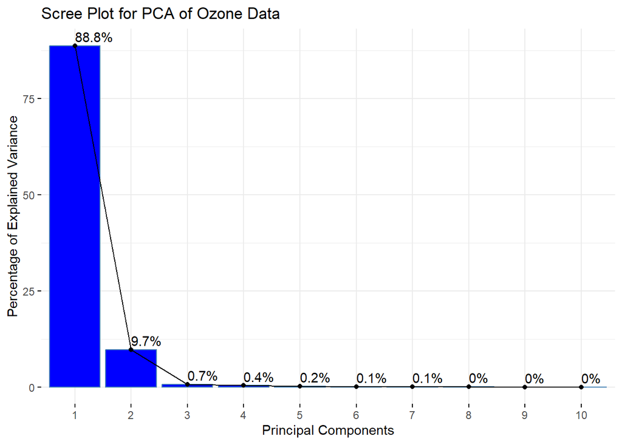

```r
#create scree plot - barplot with line
fviz_eig(pca2,
         addlabels = TRUE,
         main = "Scree Plot for PCA of Ozone Data",
         xlab = "Principal Components",
         ylab = "Percentage of Explained Variance",
         barfill = "blue",
         linecolor = 'black'
)
```

There are two visible elbows in the line plot in the above graph at the 1st and 2nd Principal components, then the line is relatively straight for the remaining PCs. This shows that the differences in percentage of explained variance is negligible from `Comp.3` to `Comp.10` .

#### 3. Bi-plot

I visualised the contribution of each variable to the first two principle components using a biplot, to further analyse the contribution of each variable to the principle components.

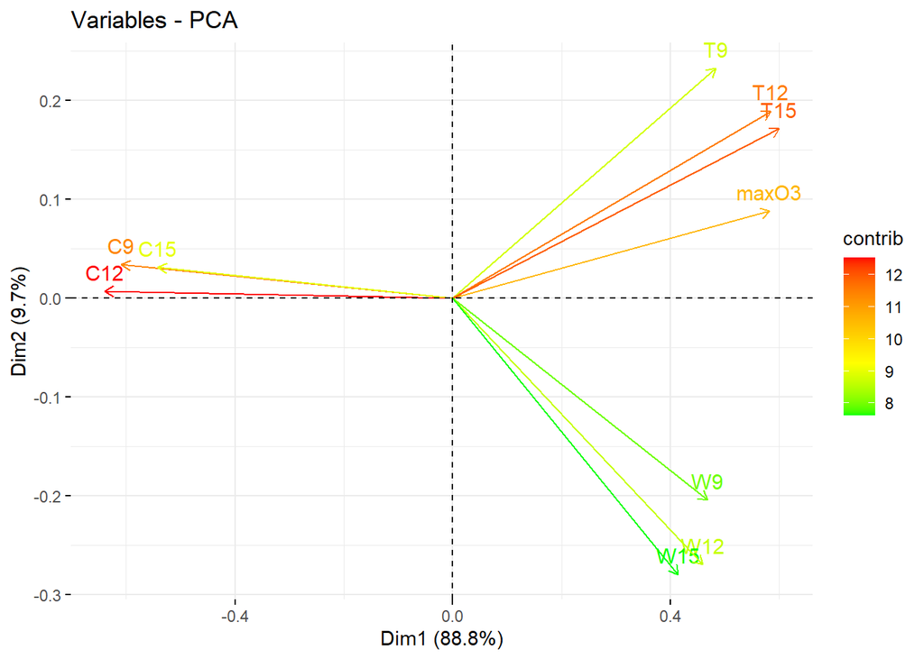

```r
# Graph of the variables
fviz_pca_var(data.pca, col.var = "contrib", gradient.cols = c("green","yellow","orange","red"))
```

In the above bi-plot, the first principle component (`Comp.1`) is represented as the x-axis and the second principle component (`Comp.2`) is represented as the y-axis.

#### 4. Examination of PC Loadings

I obtained the PC loadings automatically calculated using the `princomp()` function, in order to examine the correlation between the original variables and the principal components. I specifically loaded only the first and second principal components which explain a high amount of the variance observed in the graph.

```r
# get the pca loadings
data.pca$loadings [, 1:2]
```

```
##           Comp.1      Comp.2
## maxO3  0.3389565  0.15504625
## T9     0.2815047  0.41024776
## T12    0.3402027  0.33320414
## T15    0.3493534  0.30228883
## C9    -0.3547057  0.05951707
## C12   -0.3728218  0.01237120
## C15   -0.3155644  0.05523427
## W9     0.2724735 -0.35976238
## W12    0.2671010 -0.47557330
## W15    0.2410393 -0.49285780
```

**First Principal Component - Interpretation**

Taking a significance level of $\rho \geq 0.34$, we can interpret that:

The variables with the highest correlation with the first principal component are `maxO3` , `T15` and `T12` in the positive direction, and `C12` and `C9` in the negative direction.

With specific respect to the `maxO3` variable, This implies that the maximum daily ozone levels are positively correlated with `T15` and `T12` , thus the higher temperatures in the afternoon and onwards are associated with higher maximum levels of ozone recorded for the day.

Furthermore, `maxO3` is negatively correlated with `C12` and `C9` , implying that lower levels of cloud cover at and before noon hours are associated with higher maximum levels of ozone recorded for the day.

**Second Principal Component - Interpretation**

Taking the same significance level of $\rho \geq 0.34$, we can interpret that:

The variables with the highest correlation with the second principal component are `T9` in the positive direction, and `W15` , `W12` and `W9` in the negative direction.